# chapter2: Regression and model validation

- This week course excersie will focus on Regression analyses and running the model for the data of our interest.
- Prior to regression and model validation, we looked deep into the data, understood it attributes and have worked with redefining name of some varibales and created a subset by seleccting variables of our interest for further analyses.

## Reading the data

```r
setwd("~/IODS-project")
learning2014 <- read.table("~/IODS-project/data/learning2014.txt")
str(learning2014)
```

```
## 'data.frame':    166 obs. of  7 variables:
##  $ gender  : Factor w/ 2 levels "F","M": 1 2 1 2 2 1 2 1 2 1 ...
##  $ age     : int  53 55 49 53 49 38 50 37 37 42 ...
##  $ attitude: num  3.7 3.1 2.5 3.5 3.7 3.8 3.5 2.9 3.8 2.1 ...
##  $ deep    : num  3.58 2.92 3.5 3.5 3.67 ...
##  $ stra    : num  3.38 2.75 3.62 3.12 3.62 ...
##  $ surf    : num  2.58 3.17 2.25 2.25 2.83 ...
##  $ points  : int  25 12 24 10 22 21 21 31 24 26 ...
```

```r
dim(learning2014)
```

```
## [1] 166   7
```

### Comment on structure and dimension of the data

- The data frame contains 7 variables with 166 observations where age and points are presented as integers and attitude, deep, stra and surf are presented as numbers.
- Gender is presented with two factor levels, male (M) and female (F).

## Exploring the data

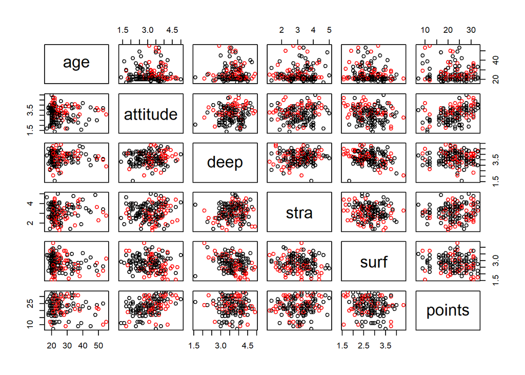

```r
pairs(learning2014[!names(learning2014) %in% c("gender")],col=learning2014$gender)
```

```r
library(GGally)
```

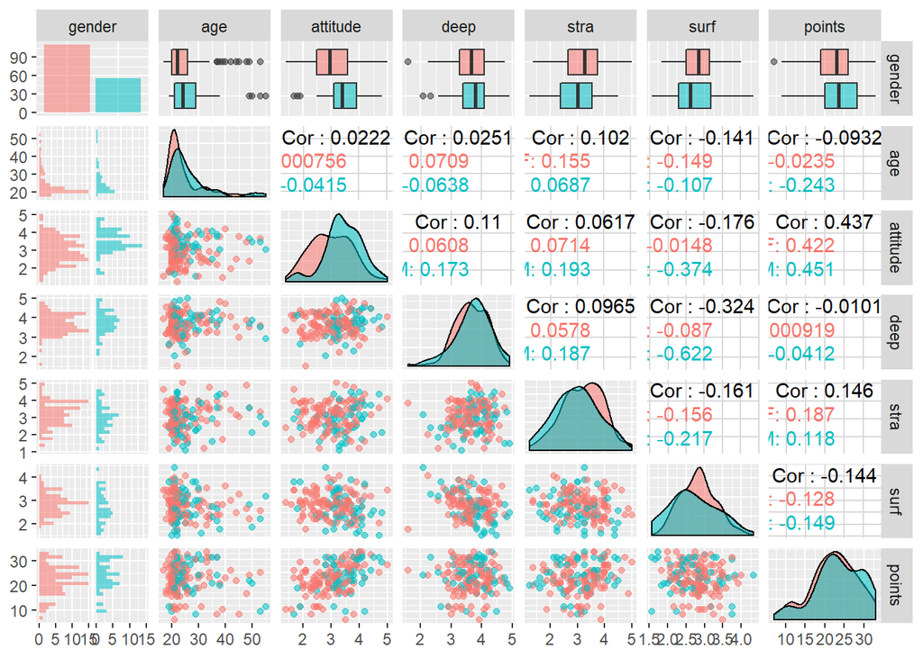

```r
library(ggplot2)
ggpairs(learning2014,
        mapping = aes(col = gender, alpha = 0.3),
        lower = list(combo = wrap("facethist", bins = 20)))
```

### Interpreting the data

- If we look at the main daiganol (skewed distribution) and first column (histograms), among all variables *age* of the gender is highly skewed whereas *stra* is skewed very minimal.
- High skeweness in age is also visible from box plots as it shows many outliers above whiskers (error bars). Minimal skweness in *stra* variable could be also seen in the box plot of *stra* where medians for both genders lies almost at the center of the box.
- Highest correlation is seen between *attitude* and *points*; **Cor:** 0.4365245 .
- Lowest correlation is seen between *deep* and *surf*; **Cor:** -0.323802 .